# SIQR: An R Package for Single-index Quantile Regression

We develop an R package *SIQR* that implements the single-index quantile regression (SIQR) models via an efficient iterative local linear approach in (Wu et al. 2010). Single-index quantile regression models are important tools in semiparametric regression to provide a comprehensive view of the conditional distributions of a response variable. It is especially useful when the data is heterogeneous or heavy-tailed. The package provides functions that allow users to fit SIQR models, predict, provide standard errors of the single-index coefficients via bootstrap, and visualize the estimated univariate function. We apply the R package *SIQR* to a well-known Boston Housing data.

Tianhai Zu (University of Cincinnati) , Yan Yu (University of Cincinnati)  
2021-10-19

## 1 Introduction

Single-index quantile regression (SIQR) is a flexible semiparametric quantile regression model for analyzing heterogeneous data. The SIQR model has some appealing features: (i) It can provide a comprehensive view of the conditional distribution of a response variable given $d$-dimensional covariates by examining the full spectrum of conditional quantiles. This is especially important for complex heterogeneous data. (ii) The single-index structure is flexible to accommodate nonlinearity while avoiding the curse of dimensionality. It can also implicitly model some interactions among the covariates. Some interesting interpretations of the single-index parameter may be preserved. (iii) The quantile regression approach is robust to heavy-tailed distributions.

We present a package *SIQR* in R that implements the iterative local linear approach to the single-index quantile regression in (Wu et al. 2010). The unknown univariate function is estimated by local linear estimation. The key algorithm can be decomposed into two efficient estimation steps on augmented data through local linear approximation and some equivalent formulation of the expected loss. Essentially, it iterates between two linear quantile regressions utilizing the state-of-the-art R package *quantreg*.

We apply our R package, *SIQR*, to the well-known Boston Housing data (1978) that is available in the R default library. The data has a total of 506 observations, and the response variable of interest is the median price of owner-occupied homes on the census tracts in suburban Boston from the 1970 census. The response variable and some covariates are left-skewed. Clearly, quantile regression is a natural tool to analyze the data (e.g., Chaudhuri et al. (1997); Yu and Lu (2004); Wu et al. (2010); Kong and Xia (2012)). We organize the rest of the paper as follows. In the next section, we review the SIQR models. Next, we discuss the estimation algorithms implemented in this package. The section following describes the main features of the functions provided. Section “Real Data Analysis and Simulation” illustrates the use of *SIQR* in R for Boston housing data and a simulation study. The last section concludes the paper.

## 2 An overview for single-index quantile regression

### 2.1 Data structure and model settings

We develop an R package for the single-index quantile regression for semiparametric estimation with $d$-dimensional covariates. Let $Y$ be the response variable and $\textbf{ X}$ be the covariate vector. Suppose there are $n$ observations $\bigl\{(\textbf{ x}_i,y_i)\bigr\}_{i=1}^n$ of $(\textbf{ X}=\textbf{ x},Y=y)$. Given $\tau\in(0,1)$ and covariates $\textbf{ x}_i$, the single-index quantile model for the $\tau$-th conditional quantile of the $i$-th observation is
$$\label{eq:siqr}
q_{\tau}(Y=y_i | \textbf{ X}=\textbf{ x}_i) = g_\tau (\textbf{ x}_i \mathbf{\beta}_{\tau}), \tag{1}$$
where $y_i$ is a real valued response, covariate $\textbf{ x}_i$ is a $d$-dimensional row vector, the single-index parameter $\mathbf{\beta}_{\tau}$ is a column vector in $\textbf{ R}^d$, and the univariate function $g_{\tau}: \textbf{ R}\rightarrow \textbf{ R}$ is subject to different $\tau$. For identifiability, the single index parameter $\|\mathbf{\beta}_{\tau}\|= 1$ and the first non-zero element of $\mathbf{\beta}_{\tau}$ is positive (Yu and Ruppert 2002). The projection $\textbf{ x}\mathbf{\beta}$ is often termed as the "single index". When $g_{\tau}$ is linear, single-index quantile regression model ((1)) reduces to the seminal work of linear quantile regression of (Koenker and Bassett 1978).

### 2.2 Review of local linear estimation for single-index quantile regression

We implement the local linear estimation for single-index quantile regression ((1)) (Wu et al. 2010). For notational convenience, we omit the subscript $\tau$ in $g_\tau$ and $\mathbf{\beta}_{\tau}$. The true parameter vector $\mathbf{\beta}$ is the minimizer of
$$\label{eq loss1}
E\left[\rho_\tau\left(y-g(\textbf{ x}\mathbf{\beta})\right)\right] , \tag{2}$$
where $\rho_\tau(u)=|u|+(2\tau-1)u$ is the loss function, often termed as the “check" function in quantile regression. $g(\cdot)$ is the unknown univariate function. Constraint $\|\mathbf{\beta}\|=1, \beta_1>0$ is imposed for identifiability. The above expected loss can be equivalently written as
$$\label{eq loss2}
E\left\{E\left[\rho_\tau\left(y-g(\textbf{ x}\mathbf{\beta})\right)|\textbf{ x}\mathbf{\beta}\right]\right\}, \tag{3}$$
where $E\left[\rho_\tau\left(y-g(\textbf{ x}\mathbf{\beta})\right)|\textbf{ x}\mathbf{\beta}\right]$ is the conditional expected loss and $g(\cdot)$ is the $\tau$th conditional quantile given the single-index parameter $\mathbf{\beta}$.

We adopt a local linear approximation. In particular, for $\textbf{ x}_i\mathbf{\beta}$ "close” to $u$, we can approximate the $\tau$th conditional quantile at $\textbf{ x}_i\mathbf{\beta}$ linearly via
$$g(\textbf{ x}_i\mathbf{\beta})\approx g(u)+g'(u)(\textbf{ x}_i\mathbf{\beta}-u)=a+b(\textbf{ x}_i\mathbf{\beta}-u),$$
where we define $a{\equiv}g(u)$ and $b{\equiv}g'(u)$.

Now, we can minimize the sample analogue of ((2)) below as in (Yu and Jones 1998) with respect to $(a, b)$ with local linear estimation
$$\label{eq condloss}
\sum_{i=1}^n\rho_\tau\left(y_i-a-b(\textbf{ x}_i\mathbf{\beta}-u)\right)K\left(\frac{\textbf{ x}_i\mathbf{\beta}-u}{h}\right), \tag{4}$$
where $K(\cdot)$ is the kernel function and $h$ is the bandwidth.

Bandwidth is a critical smoothing parameter that tunes the smoothness of the fitted function in local estimation. We implement the choice of the optimal bandwidth $h_\tau$ as advocated in (Wu et al. 2010) through a computationally-expedient rule-of-thumb:
$$\label{eq approx hp}
h_{\tau}=h_m\left\{\tau(1-\tau)/\phi\left(\Phi^{-1}(\tau)\right)^2\right\}^{1/5}, \tag{7}$$
where $\phi(\cdot)$ is the probability density function and $\Phi(\cdot)$ is the cumulative distribution function of the standard normal distribution. Here, $h_m= \Bigl\{ \frac{[ \int K^2(v)dv ] [var(y|\textbf{ x}\mathbf{\beta}=u)]}{n [ \int v^2 K(v)dv ]^2 [\frac{d^2}{d u^2}E(y|\textbf{ x}\mathbf{\beta}=u)]^2 [f_{U_0}(u)]} \Bigr\}^{1/5}$ is the optimal bandwidth in mean regression, which is easily obtainable from many existing packages (Ruppert et al. 1995).

### 2.3 Algorithm

We present the main algorithm for fitting the single-index quantile regression (SIQR) with local linear estimation in detail as following:

**Input:** Quantile level $\tau\in(0,1)$, $d$-dimensional covariate vector $\textbf{ X}=\mathbf{x}$, and a response vector $Y=\mathbf{y}$.  
**Output:** The estimated quantile single-index parameter $\widehat{{\mathbf{\beta}}}_{\tau}$ and fitted conditional quantile $\hat{q}_{\tau}(Y =\textbf{ y}| \textbf{ X}=\textbf{ x})$. The univariate function estimate $\hat{g}_{\tau}(\cdot).$

## 3 The SIQR package

The R package *SIQR* consists of one core estimation function `siqr` and some supporting functions such as visualization tool `plot.siqr` and summary function `summary.siqr`. The R package SIQR depends on the R packages *stats*, [*quantreg*](https://CRAN.R-project.org/package=quantreg), [*KernSmooth*](https://CRAN.R-project.org/package=KernSmooth).

### 3.1 Main fitting function

The main estimation function `siqr` implements the iterative local linear approach to the single-index quantile regression in (Wu et al. 2010).

The usage and input arguments of the main fitting function `siqr` are summarized as follows:

```r
  siqr(y, X, tau=0.5, h=NULL, beta.initial=NULL, se.method = NULL, maxiter=30, tol=1e-8)
```

This function takes two required arguments: the response variable y in vector format, the covariate matrix X. Please note that all the input covariates are required to be numeric variables.

This function also takes several optional arguments for finer controls. The optional argument `tau` is the quantile index, which specifies the left-tail probability. The default value of `tau` is 0.5, which refers to a single-index median regression. The optional argument `h` is the bandwidth in local linear quantile regression. Users can either provide a bandwidth or let the algorithm decide the optimal bandwidth as advocated in (Wu et al. 2010) by setting this argument to NULL as default. The optional argument `beta.initial` is a numeric vector of the same length as the dimensionality of covariates. The users can use this argument to pass in any appropriate user-defined initial single-index coefficients based on prior information or domain knowledge. The default value is NULL, which instructs the function to estimate the initial single-index coefficients by linear quantile regression. The optional argument `se.method` is a character variable that specifies the method to obtain the standard error of estimated single-index coefficients. The default value is NULL to skip the calculation of standard error while the bootstrap-based method is available with "bootstrap". The optional argument `maxiter` and `tol` are control parameters that specify the criteria to terminate the iteration process. Although the algorithm normally converges quickly, the default `maxiter` and `tol` are set to 30 and 1e-8, respectively.

### 3.2 Other functions

We also provide several supporting functions:

```r
  summary.siqr(siqr.object)
  print.summary.siqr(siqr.object)
```

The functions `summary.siqr` and `print.summary.siqr` provide detailed information related to the fitted model and summarize the results as illustrated in the next section. These two functions can be called directly by applying functions print and summary to the siqr.object.

```r
  plot.siqr(siqr.object, data.points = TRUE, bootstrap.interval=FALSE)
```

This function plots the fitted quantiles against the single-index term from an SIQR-fitted model object. By default, this function will also plot the observed data points in addition to the fitted quantiles to visualize the fitness of the model. One can remove the data points by setting the optional argument `data.points` to FALSE. Pointwise confidence interval will be added to the plot if the optional argument `bootstrap.interval` is set to TRUE.

```r
  simulation_data <- generate.data(n, true.theta=NULL, sigma=0.1,
  setting="setting1", ncopy=1)
```

## 4 Real Data and Simulations

#### Boston Housing data

We consider the Boston housing data to demonstrate the real data application of the proposed R package *SIQR*. This dataset contains the median value of houses (in $1000’s), medv, in 506 tracts in Boston and 13 other socio-demographic related variables. This data has been investigated by many studies. Heterogeneity and some non-linear dependence of medv on predictor variables have been found by previous researchers. The dataset is maintained at the StatLib library of Carnegie Mellon University and can be found at the R built-in package *MASS*.

We focus on the following four covariates: RM, the average number of rooms per dwelling; TAX, the full-value property tax (in $) per $10,000; PTRATIO, the pupil-teacher ratio by town; and LSTAT, percentage of the lower status of the population as in (Opsomer and Ruppert 1998), (Yu and Lu 2004), and (Wu et al. 2010). Following previous studies, we take logarithmic transformations on TAX and LSTAT and center the dependent variable medv around zero.

We use the following codes to load data from *MASS* and pre-process as discussed above. We fit a single-index quantile regression with $\tau = 0.25,0.50,0.75$ to the data and report fitted single-index coefficients for each variable.

```r
  library(SIQR)
  #load data from MASS
  library(MASS)
  medv<- Boston$medv
  RM <- Boston$rm
  logTAX <- log(Boston$tax)
  PTRATIO <- Boston$ptratio
  logLSTAT <- log(Boston$lstat)

  X <- cbind(RM,logTAX,PTRATIO,logLSTAT)
  y0 <- medv - mean(medv)
  beta0 <- NULL
  tau.vec <- c(0.25,0.50,0.75)
  est.coefficient <- matrix(NA, nrow = length(tau.vec), ncol = 5)
  est.coefficient[,1] <- tau.vec
  for (i in 1:length(tau.vec)){
  est <- siqr(y0,X,beta.initial = beta0, tau=tau.vec[i],maxiter = 30,tol = 1e-8)
  est.coefficient[i,2:5] <- est$beta
  }
  colnames(est.coefficient) <- c("quantile tau",colnames(X))
  est.coefficient
```

```r
 #>      quantile tau        RM     logTAX     PTRATIO   logLSTAT
 #> [1,]         0.25 0.3358285 -0.5243025 -0.06856117 -0.7795033
 #> [2,]         0.50 0.3129182 -0.4294159 -0.06640472 -0.8445558
 #> [3,]         0.75 0.2385613 -0.1933015 -0.07860687 -0.9484429
```

The estimated 0.25, 0.50, and 0.75 quantiles and their 95% pointwise confidence bounds are plotted with the following codes and outputs.

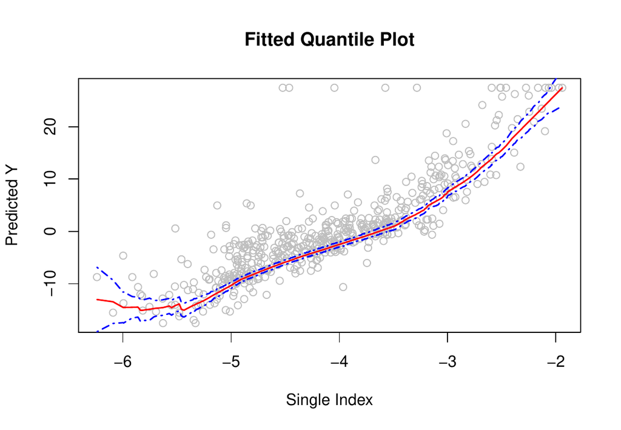

Figure 1: The R output of `plot.siqr` with estimated 0.25 quantiles and the 95% pointwise confidence bounds.

```r
  est.tau25 <- siqr(y0,X,beta.initial = NULL, tau=0.25)
  plot.siqr(est.tau25,bootstrap.interval = TRUE)
```

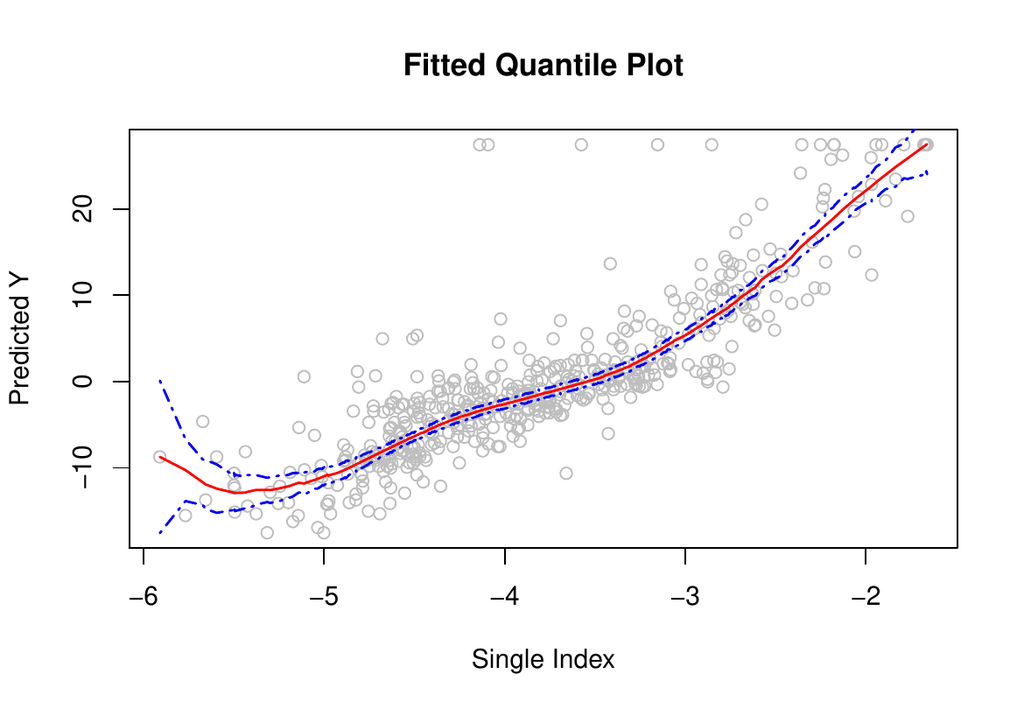

Figure 2: The R output of `plot.siqr` with estimated 0.50 quantiles and the 95% pointwise confidence bounds.

```r
  est.tau50 <- siqr(y0,X,beta.initial = NULL, tau=0.50)
  plot.siqr(est.tau05,bootstrap.interval = TRUE)
```

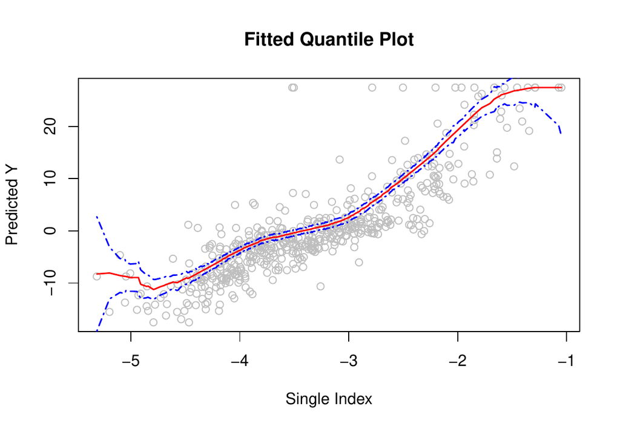

Figure 3: The R output of `plot.siqr` with estimated 0.75 quantiles and the 95% pointwise confidence bounds.

```r
  est.tau75 <- siqr(y0,X,beta.initial = NULL, tau=0.75)
  plot.siqr(est.tau75,bootstrap.interval = TRUE)
```

As the estimated single-index function curves are almost monotonically increasing across different quantiles, variables that contribute positively to the single index affect the response variable (medv) positively. Based on the estimated coefficients and above plots, we found that the number of rooms per house (rm) positively affects different quantiles. This matches the intuition that people value large spaces and multi-functional rooms. The property tax rate ln(tax) has a negative impact on housing prices across different quantiles. However, the influence of the tax rate is not significant at higher quantile $\tau$ = 0.75. That suggests the tax rate may be less concerned for higher-income households, possibly due to tax deduction towards their income tax. Both the pupil-teacher ratio (ptratio) and the percentage of the lower (educational) status of the population ln(lstat) show negative influences on housing values, especially for the higher quantiles. It may suggest that potential buyers prefer areas featuring solid educational resources for their children and neighbors with higher education degrees and that preference grows more vital for more expensive houses.

#### Simulation

We consider two simulation settings. In the first simulation example, we use a sine-bump model with homoscedastic errors:
$$\label{eq:sim1}
y=5 \sin \left(\frac{\pi \left( \textbf{ x}\mathbf{\beta}- A \right)}{C-A} \right)+ 0.1 Z, \tag{11}$$
where $A=\frac{\sqrt{3}}{2}-\frac{1.645}{\sqrt{12}}, C=\frac{\sqrt{3}}{2}+\frac{1.645}{\sqrt{12}}$, $\textbf{ x}$ is an $n\times3$ design matrix that draws from an independent uniform distribution with min of 0 and max of 1, and the residual $Z$ follows a standard normal distribution. The true single-index parameter $\mathbf{\beta}= (1,1,1)^{\intercal} / \sqrt{3}$.

Table 1: Summary of parameter estimates for sine-bump simulation example 1 of sample size $n=400$. True $\mathbf{\beta}= (1,1,1)^{\intercal} / \sqrt{3}$. The sample mean, standard error (s.e.), and bias of the parameter estimates of single-index coefficients from 200 replications.

[output not shown]

The single-index coefficients are estimated via a series of quantile regressions with $\tau = 0.25, 0.50, 0.75.$ Table 1 reports the mean, standard error (s.e.), and bias for each parameter estimate with sample size $n=400$ over $M=200$ replications on the simulation example 1. One can see that the algorithm for our R package *SIQR* is effective as the estimates are close to the true values.

For demonstration purposes, we show codes to generate data from ((11)) and fit the SIQR model using $\tau = 0.50$ with 200 replications as follows:

```r
 n <- 400
 beta0 <- c(1, 1, 1)/sqrt(3)
 n.sim <- 200
 tau <- 0.50
 data <- generate.data(n, true.theta=beta0, setting = "setting1",ncopy = n.sim)
 sim.results.50 <- foreach(m = 1:n.sim,.combine = "rbind") %do% {
 X <- data$X
 Y <- data$Y[[m]]
 est <- siqr(Y, X, beta.initial = c(2,1,0), tau=0.50,maxiter = 30,tol = 1e-8)
 return(est$beta)
}
```

Note that this process has been repeated for the cases with $\tau = 0.25, 0.75$. We obtain a box plot of estimated single-index coefficients for $\tau = 0.25, 0.50, 0.75$, respectively, by applying the following code snippet.

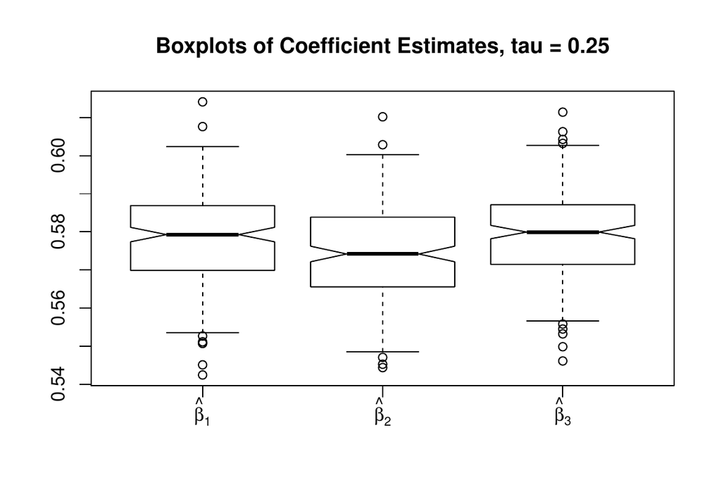

Figure 4: The box plot of estimated single-index coefficients for $\tau = 0.25$ from example 1.

```r
 boxplot(data.frame((sim.results.25)), outline=T,notch=T,range=1,
 main = "Boxplots of Coefficient Estimates, tau = 0.25",horizontal = F)
```

[figure not shown]

Figure 5: The box plot of estimated single-index coefficients for $\tau = 0.50$ from example 1.

```r
 boxplot(data.frame((sim.results.50)), outline=T,notch=T,range=1,
 main = "Boxplots of Coefficient , tau = 0.50",horizontal = F)
```

[figure not shown]

Figure 6: The box plot of estimated single-index coefficients for $\tau = 0.75$ from example 1.

```r
 boxplot(data.frame((sim.results.75)), outline=T,notch=T,range=1,
 main = "Boxplots of Coefficient Estimates, tau = 0.75",horizontal = F)
```